# Risk Factor Analysis

## Outcome Variable

**Outcome Variable:** stunted

## Predictor Variables

**Intervention Variable:** gagebrth

**Adjustment Set:**

- arm
- sex
- W_mage
- meducyrs
- feducyrs
- hhwealth_quart
- W_nrooms
- W_nchldlt5
- brthmon
- W_parity
- impfloor
- impsan
- safeh20
- delta_W_mage
- delta_meducyrs
- delta_feducyrs
- delta_hhwealth_quart
- delta_W_nrooms
- delta_W_nchldlt5
- delta_brthmon
- delta_W_parity
- delta_impfloor
- delta_impsan
- delta_safeh20

## Stratifying Variables

The analysis was stratified on these variable(s):

- agecat
- studyid
- country

## Data Summary

| agecat | studyid | country | gagebrth | stunted | n_cell | n |
| --- | --- | --- | --- | --- | --- | --- |
| Birth | ki1000108-CMC-V-BCS-2002 | INDIA | Full or late term | 0 | 47 | 90 |
| Birth | ki1000108-CMC-V-BCS-2002 | INDIA | Full or late term | 1 | 10 | 90 |
| Birth | ki1000108-CMC-V-BCS-2002 | INDIA | Preterm | 0 | 8 | 90 |
| Birth | ki1000108-CMC-V-BCS-2002 | INDIA | Preterm | 1 | 2 | 90 |
| Birth | ki1000108-CMC-V-BCS-2002 | INDIA | Early term | 0 | 19 | 90 |
| Birth | ki1000108-CMC-V-BCS-2002 | INDIA | Early term | 1 | 4 | 90 |
| Birth | ki1000108-IRC | INDIA | Full or late term | 0 | 211 | 369 |
| Birth | ki1000108-IRC | INDIA | Full or late term | 1 | 27 | 369 |
| Birth | ki1000108-IRC | INDIA | Preterm | 0 | 27 | 369 |
| Birth | ki1000108-IRC | INDIA | Preterm | 1 | 9 | 369 |
| Birth | ki1000108-IRC | INDIA | Early term | 0 | 87 | 369 |
| Birth | ki1000108-IRC | INDIA | Early term | 1 | 8 | 369 |
| Birth | ki1000109-EE | PAKISTAN | Full or late term | 0 | 0 | 4 |
| Birth | ki1000109-EE | PAKISTAN | Full or late term | 1 | 0 | 4 |
| Birth | ki1000109-EE | PAKISTAN | Preterm | 0 | 0 | 4 |
| Birth | ki1000109-EE | PAKISTAN | Preterm | 1 | 2 | 4 |
| Birth | ki1000109-EE | PAKISTAN | Early term | 0 | 2 | 4 |
| Birth | ki1000109-EE | PAKISTAN | Early term | 1 | 0 | 4 |
| Birth | ki1000304b-SAS-CompFeed | INDIA | Full or late term | 0 | 1 | 187 |
| Birth | ki1000304b-SAS-CompFeed | INDIA | Full or late term | 1 | 0 | 187 |
| Birth | ki1000304b-SAS-CompFeed | INDIA | Preterm | 0 | 128 | 187 |
| Birth | ki1000304b-SAS-CompFeed | INDIA | Preterm | 1 | 43 | 187 |
| Birth | ki1000304b-SAS-CompFeed | INDIA | Early term | 0 | 12 | 187 |
| Birth | ki1000304b-SAS-CompFeed | INDIA | Early term | 1 | 3 | 187 |
| Birth | ki1017093c-NIH-Crypto | BANGLADESH | Full or late term | 0 | 5 | 27 |
| Birth | ki1017093c-NIH-Crypto | BANGLADESH | Full or late term | 1 | 2 | 27 |
| Birth | ki1017093c-NIH-Crypto | BANGLADESH | Preterm | 0 | 3 | 27 |
| Birth | ki1017093c-NIH-Crypto | BANGLADESH | Preterm | 1 | 2 | 27 |
| Birth | ki1017093c-NIH-Crypto | BANGLADESH | Early term | 0 | 14 | 27 |
| Birth | ki1017093c-NIH-Crypto | BANGLADESH | Early term | 1 | 1 | 27 |

[output cut: 168 more lines]

The following strata were considered:

- agecat: 24 months, studyid: ki1000108-CMC-V-BCS-2002, country: INDIA
- agecat: 24 months, studyid: ki1000108-IRC, country: INDIA
- agecat: 24 months, studyid: ki1017093c-NIH-Crypto, country: BANGLADESH
- agecat: 24 months, studyid: ki1066203-TanzaniaChild2, country: TANZANIA, UNITED REPUBLIC OF
- agecat: 24 months, studyid: ki1101329-Keneba, country: GAMBIA
- agecat: 24 months, studyid: ki1119695-PROBIT, country: BELARUS
- agecat: 24 months, studyid: ki1135781-COHORTS, country: GUATEMALA
- agecat: 24 months, studyid: ki1135781-COHORTS, country: INDIA
- agecat: 24 months, studyid: ki1135781-COHORTS, country: PHILIPPINES
- agecat: 24 months, studyid: kiGH5241-JiVitA-3, country: BANGLADESH
- agecat: 6 months, studyid: ki1000108-CMC-V-BCS-2002, country: INDIA
- agecat: 6 months, studyid: ki1000108-IRC, country: INDIA
- agecat: 6 months, studyid: ki1000109-EE, country: PAKISTAN
- agecat: 6 months, studyid: ki1000304b-SAS-CompFeed, country: INDIA
- agecat: 6 months, studyid: ki1017093c-NIH-Crypto, country: BANGLADESH
- agecat: 6 months, studyid: ki1066203-TanzaniaChild2, country: TANZANIA, UNITED REPUBLIC OF
- agecat: 6 months, studyid: ki1101329-Keneba, country: GAMBIA
- agecat: 6 months, studyid: ki1119695-PROBIT, country: BELARUS
- agecat: 6 months, studyid: ki1135781-COHORTS, country: GUATEMALA
- agecat: 6 months, studyid: ki1135781-COHORTS, country: INDIA
- agecat: 6 months, studyid: ki1135781-COHORTS, country: PHILIPPINES
- agecat: 6 months, studyid: kiGH5241-JiVitA-3, country: BANGLADESH
- agecat: Birth, studyid: ki1000108-CMC-V-BCS-2002, country: INDIA
- agecat: Birth, studyid: ki1000108-IRC, country: INDIA
- agecat: Birth, studyid: ki1000109-EE, country: PAKISTAN
- agecat: Birth, studyid: ki1000304b-SAS-CompFeed, country: INDIA
- agecat: Birth, studyid: ki1017093c-NIH-Crypto, country: BANGLADESH
- agecat: Birth, studyid: ki1101329-Keneba, country: GAMBIA
- agecat: Birth, studyid: ki1119695-PROBIT, country: BELARUS
- agecat: Birth, studyid: ki1135781-COHORTS, country: GUATEMALA
- agecat: Birth, studyid: ki1135781-COHORTS, country: INDIA
- agecat: Birth, studyid: ki1135781-COHORTS, country: PHILIPPINES
- agecat: Birth, studyid: kiGH5241-JiVitA-3, country: BANGLADESH

### Dropped Strata

Some strata were dropped due to rare outcomes:

- agecat: Birth, studyid: ki1000108-CMC-V-BCS-2002, country: INDIA
- agecat: Birth, studyid: ki1000109-EE, country: PAKISTAN
- agecat: Birth, studyid: ki1000304b-SAS-CompFeed, country: INDIA
- agecat: Birth, studyid: ki1017093c-NIH-Crypto, country: BANGLADESH
- agecat: 6 months, studyid: ki1000304b-SAS-CompFeed, country: INDIA
- agecat: 24 months, studyid: ki1066203-TanzaniaChild2, country: TANZANIA, UNITED REPUBLIC OF

## Methods Detail

We’re interested in the causal parameters $E[Y_a]$ for all values of $a \in \mathcal{A}$. These parameters represent the mean outcome if, possibly contrary to fact, we intervened to set all units to have $A=a$. Under the randomization and positivity assumptions, these are identified by the statistical parameters $\psi_a=E_W[E_{Y|A,W}(Y|A=a,W)]$. In addition, we’re interested in the mean of $Y$, $E[Y]$ under no intervention (the observed mean). We will estimate these parameters by using SuperLearner to fit the relevant likelihood factors – $E_{Y|A,W}(Y|A=a,W)$ and $p(A=a|W)$, and then updating our likelihood fit using a joint TMLE.

For unadjusted analyses ($W=\{\}$), initial likelihoods were estimated using Lrnr_glm to estimate the simple $E(Y|A)$ and Lrnr_mean to estimate $p(A)$. For adjusted analyses, a small library containing Lrnr_glmnet, Lrnr_xgboost, and Lrnr_mean was used.

Having estimated these parameters, we will then use the delta method to estimate relative risks and attributable risks relative to a prespecified baseline level of $A$.

# Results Detail

## Results Plots

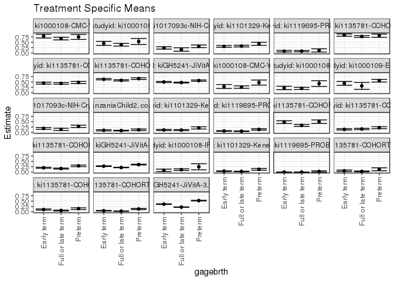

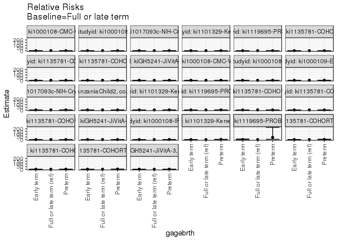

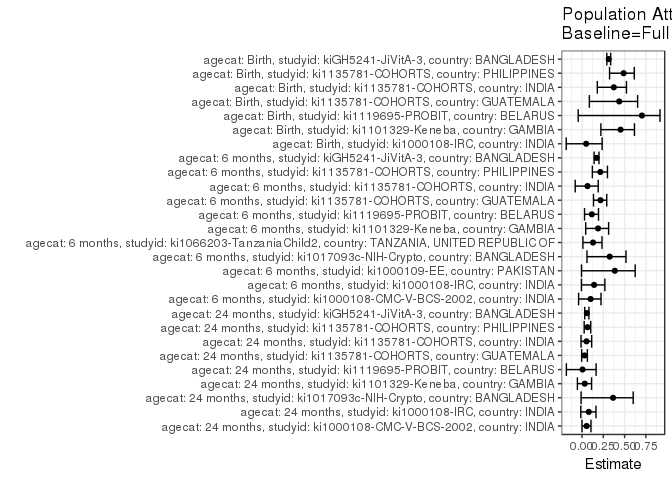

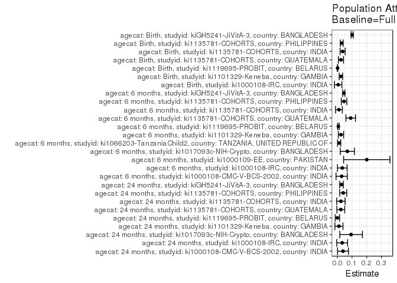

## Results Table

### Parameter: TSM

| agecat | studyid | country | intervention_level | baseline_level | estimate | ci_lower | ci_upper |
| --- | --- | --- | --- | --- | --- | --- | --- |
| Birth | ki1000108-IRC | INDIA | Full or late term | NA | 0.1134454 | 0.0730999 | 0.1537909 |
| Birth | ki1000108-IRC | INDIA | Preterm | NA | 0.2500000 | 0.1083597 | 0.3916403 |
| Birth | ki1000108-IRC | INDIA | Early term | NA | 0.0842105 | 0.0282919 | 0.1401292 |
| Birth | ki1101329-Keneba | GAMBIA | Full or late term | NA | 0.0296056 | 0.0173362 | 0.0418750 |
| Birth | ki1101329-Keneba | GAMBIA | Preterm | NA | 0.1292840 | 0.0866751 | 0.1718928 |
| Birth | ki1101329-Keneba | GAMBIA | Early term | NA | 0.0437939 | 0.0264876 | 0.0611002 |
| Birth | ki1119695-PROBIT | BELARUS | Full or late term | NA | 0.0007047 | -0.0002052 | 0.0016147 |
| Birth | ki1119695-PROBIT | BELARUS | Preterm | NA | 0.0296610 | -0.0004536 | 0.0597756 |
| Birth | ki1119695-PROBIT | BELARUS | Early term | NA | 0.0022162 | 0.0011584 | 0.0032741 |
| Birth | ki1135781-COHORTS | GUATEMALA | Full or late term | NA | 0.0319378 | 0.0131593 | 0.0507162 |
| Birth | ki1135781-COHORTS | GUATEMALA | Preterm | NA | 0.1318290 | 0.0633900 | 0.2002680 |
| Birth | ki1135781-COHORTS | GUATEMALA | Early term | NA | 0.0596564 | 0.0249856 | 0.0943272 |
| Birth | ki1135781-COHORTS | INDIA | Full or late term | NA | 0.0600530 | 0.0408640 | 0.0792420 |
| Birth | ki1135781-COHORTS | INDIA | Preterm | NA | 0.1474790 | 0.1076317 | 0.1873262 |
| Birth | ki1135781-COHORTS | INDIA | Early term | NA | 0.1065450 | 0.0781697 | 0.1349203 |
| Birth | ki1135781-COHORTS | PHILIPPINES | Full or late term | NA | 0.0312791 | 0.0214707 | 0.0410874 |
| Birth | ki1135781-COHORTS | PHILIPPINES | Preterm | NA | 0.1318867 | 0.1064816 | 0.1572918 |
| Birth | ki1135781-COHORTS | PHILIPPINES | Early term | NA | 0.0502090 | 0.0380506 | 0.0623673 |
| Birth | kiGH5241-JiVitA-3 | BANGLADESH | Full or late term | NA | 0.2198413 | 0.2103266 | 0.2293559 |
| Birth | kiGH5241-JiVitA-3 | BANGLADESH | Preterm | NA | 0.5229359 | 0.5060100 | 0.5398618 |
| Birth | kiGH5241-JiVitA-3 | BANGLADESH | Early term | NA | 0.3586688 | 0.3441920 | 0.3731457 |
| 6 months | ki1000108-CMC-V-BCS-2002 | INDIA | Full or late term | NA | 0.2616554 | 0.2034386 | 0.3198722 |
| 6 months | ki1000108-CMC-V-BCS-2002 | INDIA | Preterm | NA | 0.4720938 | 0.3525586 | 0.5916290 |
| 6 months | ki1000108-CMC-V-BCS-2002 | INDIA | Early term | NA | 0.2876339 | 0.1957432 | 0.3795246 |
| 6 months | ki1000108-IRC | INDIA | Full or late term | NA | 0.2034910 | 0.1537486 | 0.2532333 |
| 6 months | ki1000108-IRC | INDIA | Preterm | NA | 0.4278038 | 0.2933787 | 0.5622289 |
| 6 months | ki1000108-IRC | INDIA | Early term | NA | 0.2214850 | 0.1419463 | 0.3010237 |
| 6 months | ki1000109-EE | PAKISTAN | Full or late term | NA | 0.3188763 | 0.1571202 | 0.4806324 |
| 6 months | ki1000109-EE | PAKISTAN | Preterm | NA | 0.5591971 | 0.4969389 | 0.6214554 |
| 6 months | ki1000109-EE | PAKISTAN | Early term | NA | 0.4352901 | 0.3457938 | 0.5247865 |

[output cut: 51 more lines]

### Parameter: E(Y)

| agecat | studyid | country | intervention_level | baseline_level | estimate | ci_lower | ci_upper |
| --- | --- | --- | --- | --- | --- | --- | --- |
| Birth | ki1000108-IRC | INDIA | NA | NA | 0.1192412 | 0.0861307 | 0.1523517 |
| Birth | ki1101329-Keneba | GAMBIA | NA | NA | 0.0541254 | 0.0427281 | 0.0655227 |
| Birth | ki1119695-PROBIT | BELARUS | NA | NA | 0.0023768 | 0.0010945 | 0.0036592 |
| Birth | ki1135781-COHORTS | GUATEMALA | NA | NA | 0.0567261 | 0.0384591 | 0.0749931 |
| Birth | ki1135781-COHORTS | INDIA | NA | NA | 0.0959010 | 0.0798450 | 0.1119570 |
| Birth | ki1135781-COHORTS | PHILIPPINES | NA | NA | 0.0611772 | 0.0526341 | 0.0697204 |
| Birth | kiGH5241-JiVitA-3 | BANGLADESH | NA | NA | 0.3205490 | 0.3127517 | 0.3283463 |
| 6 months | ki1000108-CMC-V-BCS-2002 | INDIA | NA | NA | 0.2910663 | 0.2432023 | 0.3389303 |
| 6 months | ki1000108-IRC | INDIA | NA | NA | 0.2371134 | 0.1947393 | 0.2794875 |
| 6 months | ki1000109-EE | PAKISTAN | NA | NA | 0.5188172 | 0.4679751 | 0.5696593 |
| 6 months | ki1017093c-NIH-Crypto | BANGLADESH | NA | NA | 0.2097902 | 0.1799252 | 0.2396552 |
| 6 months | ki1066203-TanzaniaChild2 | TANZANIA, UNITED REPUBLIC OF | NA | NA | 0.0956385 | 0.0824215 | 0.1088554 |
| 6 months | ki1101329-Keneba | GAMBIA | NA | NA | 0.1317322 | 0.1138432 | 0.1496212 |
| 6 months | ki1119695-PROBIT | BELARUS | NA | NA | 0.0626864 | 0.0488489 | 0.0765238 |
| 6 months | ki1135781-COHORTS | GUATEMALA | NA | NA | 0.4193548 | 0.3831093 | 0.4556004 |
| 6 months | ki1135781-COHORTS | INDIA | NA | NA | 0.1692073 | 0.1489117 | 0.1895030 |
| 6 months | ki1135781-COHORTS | PHILIPPINES | NA | NA | 0.2113882 | 0.1959475 | 0.2268289 |
| 6 months | kiGH5241-JiVitA-3 | BANGLADESH | NA | NA | 0.2583126 | 0.2488924 | 0.2677329 |
| 24 months | ki1000108-CMC-V-BCS-2002 | INDIA | NA | NA | 0.7114286 | 0.6638920 | 0.7589651 |
| 24 months | ki1000108-IRC | INDIA | NA | NA | 0.4153846 | 0.3664142 | 0.4643550 |
| 24 months | ki1017093c-NIH-Crypto | BANGLADESH | NA | NA | 0.2568093 | 0.2190047 | 0.2946140 |
| 24 months | ki1101329-Keneba | GAMBIA | NA | NA | 0.3321799 | 0.3050172 | 0.3593427 |
| 24 months | ki1119695-PROBIT | BELARUS | NA | NA | 0.0852540 | 0.0554439 | 0.1150642 |
| 24 months | ki1135781-COHORTS | GUATEMALA | NA | NA | 0.7948718 | 0.7641122 | 0.8256314 |
| 24 months | ki1135781-COHORTS | INDIA | NA | NA | 0.4579511 | 0.4309402 | 0.4849620 |
| 24 months | ki1135781-COHORTS | PHILIPPINES | NA | NA | 0.6175743 | 0.5982239 | 0.6369246 |
| 24 months | kiGH5241-JiVitA-3 | BANGLADESH | NA | NA | 0.5004236 | 0.4856838 | 0.5151635 |

### Parameter: RR

| agecat | studyid | country | intervention_level | baseline_level | estimate | ci_lower | ci_upper |
| --- | --- | --- | --- | --- | --- | --- | --- |
| Birth | ki1000108-IRC | INDIA | Full or late term | Full or late term | 1.0000000 | 1.0000000 | 1.000000 |
| Birth | ki1000108-IRC | INDIA | Preterm | Full or late term | 2.2037037 | 1.1288592 | 4.301963 |
| Birth | ki1000108-IRC | INDIA | Early term | Full or late term | 0.7423002 | 0.3494922 | 1.576600 |
| Birth | ki1101329-Keneba | GAMBIA | Full or late term | Full or late term | 1.0000000 | 1.0000000 | 1.000000 |
| Birth | ki1101329-Keneba | GAMBIA | Preterm | Full or late term | 4.3668757 | 2.5731040 | 7.411128 |
| Birth | ki1101329-Keneba | GAMBIA | Early term | Full or late term | 1.4792426 | 0.8345088 | 2.622092 |
| Birth | ki1119695-PROBIT | BELARUS | Full or late term | Full or late term | 1.0000000 | 1.0000000 | 1.000000 |
| Birth | ki1119695-PROBIT | BELARUS | Preterm | Full or late term | 42.0889831 | 7.7901583 | 227.400064 |
| Birth | ki1119695-PROBIT | BELARUS | Early term | Full or late term | 3.1448472 | 0.7336051 | 13.481455 |
| Birth | ki1135781-COHORTS | GUATEMALA | Full or late term | Full or late term | 1.0000000 | 1.0000000 | 1.000000 |
| Birth | ki1135781-COHORTS | GUATEMALA | Preterm | Full or late term | 4.1276835 | 1.8846337 | 9.040362 |
| Birth | ki1135781-COHORTS | GUATEMALA | Early term | Full or late term | 1.8678953 | 0.8172073 | 4.269459 |
| Birth | ki1135781-COHORTS | INDIA | Full or late term | Full or late term | 1.0000000 | 1.0000000 | 1.000000 |
| Birth | ki1135781-COHORTS | INDIA | Preterm | Full or late term | 2.4558146 | 1.6171616 | 3.729390 |
| Birth | ki1135781-COHORTS | INDIA | Early term | Full or late term | 1.7741841 | 1.1709365 | 2.688215 |
| Birth | ki1135781-COHORTS | PHILIPPINES | Full or late term | Full or late term | 1.0000000 | 1.0000000 | 1.000000 |
| Birth | ki1135781-COHORTS | PHILIPPINES | Preterm | Full or late term | 4.2164524 | 2.9198313 | 6.088869 |
| Birth | ki1135781-COHORTS | PHILIPPINES | Early term | Full or late term | 1.6051948 | 1.0808430 | 2.383927 |
| Birth | kiGH5241-JiVitA-3 | BANGLADESH | Full or late term | Full or late term | 1.0000000 | 1.0000000 | 1.000000 |
| Birth | kiGH5241-JiVitA-3 | BANGLADESH | Preterm | Full or late term | 2.3786973 | 2.2531730 | 2.511215 |
| Birth | kiGH5241-JiVitA-3 | BANGLADESH | Early term | Full or late term | 1.6314900 | 1.5401564 | 1.728240 |
| 6 months | ki1000108-CMC-V-BCS-2002 | INDIA | Full or late term | Full or late term | 1.0000000 | 1.0000000 | 1.000000 |
| 6 months | ki1000108-CMC-V-BCS-2002 | INDIA | Preterm | Full or late term | 1.8042577 | 1.2887279 | 2.526015 |
| 6 months | ki1000108-CMC-V-BCS-2002 | INDIA | Early term | Full or late term | 1.0992851 | 0.7454442 | 1.621084 |
| 6 months | ki1000108-IRC | INDIA | Full or late term | Full or late term | 1.0000000 | 1.0000000 | 1.000000 |
| 6 months | ki1000108-IRC | INDIA | Preterm | Full or late term | 2.1023234 | 1.4117792 | 3.130634 |
| 6 months | ki1000108-IRC | INDIA | Early term | Full or late term | 1.0884266 | 0.7048249 | 1.680804 |
| 6 months | ki1000109-EE | PAKISTAN | Full or late term | Full or late term | 1.0000000 | 1.0000000 | 1.000000 |
| 6 months | ki1000109-EE | PAKISTAN | Preterm | Full or late term | 1.7536491 | 1.0436752 | 2.946592 |
| 6 months | ki1000109-EE | PAKISTAN | Early term | Full or late term | 1.3650752 | 0.7900868 | 2.358513 |

[output cut: 51 more lines]

### Parameter: PAR

| agecat | studyid | country | intervention_level | baseline_level | estimate | ci_lower | ci_upper |
| --- | --- | --- | --- | --- | --- | --- | --- |
| Birth | ki1000108-IRC | INDIA | Full or late term | NA | 0.0057958 | -0.0191902 | 0.0307818 |
| Birth | ki1101329-Keneba | GAMBIA | Full or late term | NA | 0.0245198 | 0.0129543 | 0.0360854 |
| Birth | ki1119695-PROBIT | BELARUS | Full or late term | NA | 0.0016721 | 0.0003118 | 0.0030325 |
| Birth | ki1135781-COHORTS | GUATEMALA | Full or late term | NA | 0.0247883 | 0.0075611 | 0.0420156 |
| Birth | ki1135781-COHORTS | INDIA | Full or late term | NA | 0.0358480 | 0.0186423 | 0.0530537 |
| Birth | ki1135781-COHORTS | PHILIPPINES | Full or late term | NA | 0.0298982 | 0.0202115 | 0.0395849 |
| Birth | kiGH5241-JiVitA-3 | BANGLADESH | Full or late term | NA | 0.1007077 | 0.0933125 | 0.1081030 |
| 6 months | ki1000108-CMC-V-BCS-2002 | INDIA | Full or late term | NA | 0.0294109 | -0.0089247 | 0.0677464 |
| 6 months | ki1000108-IRC | INDIA | Full or late term | NA | 0.0336224 | 0.0008255 | 0.0664194 |
| 6 months | ki1000109-EE | PAKISTAN | Full or late term | NA | 0.1999409 | 0.0425404 | 0.3573414 |
| 6 months | ki1017093c-NIH-Crypto | BANGLADESH | Full or late term | NA | 0.0682354 | 0.0199902 | 0.1164806 |
| 6 months | ki1066203-TanzaniaChild2 | TANZANIA, UNITED REPUBLIC OF | Full or late term | NA | 0.0124029 | 0.0016224 | 0.0231833 |
| 6 months | ki1101329-Keneba | GAMBIA | Full or late term | NA | 0.0248846 | 0.0070582 | 0.0427109 |
| 6 months | ki1119695-PROBIT | BELARUS | Full or late term | NA | 0.0072372 | 0.0019384 | 0.0125360 |
| 6 months | ki1135781-COHORTS | GUATEMALA | Full or late term | NA | 0.0908135 | 0.0582494 | 0.1233776 |
| 6 months | ki1135781-COHORTS | INDIA | Full or late term | NA | 0.0109335 | -0.0118743 | 0.0337413 |
| 6 months | ki1135781-COHORTS | PHILIPPINES | Full or late term | NA | 0.0454914 | 0.0266576 | 0.0643252 |
| 6 months | kiGH5241-JiVitA-3 | BANGLADESH | Full or late term | NA | 0.0441792 | 0.0367322 | 0.0516261 |
| 24 months | ki1000108-CMC-V-BCS-2002 | INDIA | Full or late term | NA | 0.0385344 | 0.0014309 | 0.0756380 |
| 24 months | ki1000108-IRC | INDIA | Full or late term | NA | 0.0327791 | -0.0041078 | 0.0696661 |
| 24 months | ki1017093c-NIH-Crypto | BANGLADESH | Full or late term | NA | 0.0937272 | 0.0170439 | 0.1704105 |
| 24 months | ki1101329-Keneba | GAMBIA | Full or late term | NA | 0.0108299 | -0.0167808 | 0.0384407 |
| 24 months | ki1119695-PROBIT | BELARUS | Full or late term | NA | 0.0005150 | -0.0143274 | 0.0153575 |
| 24 months | ki1135781-COHORTS | GUATEMALA | Full or late term | NA | 0.0236866 | -0.0028628 | 0.0502360 |
| 24 months | ki1135781-COHORTS | INDIA | Full or late term | NA | 0.0242171 | -0.0044206 | 0.0528548 |
| 24 months | ki1135781-COHORTS | PHILIPPINES | Full or late term | NA | 0.0399848 | 0.0163358 | 0.0636337 |
| 24 months | kiGH5241-JiVitA-3 | BANGLADESH | Full or late term | NA | 0.0284419 | 0.0160985 | 0.0407853 |

### Parameter: PAF

| agecat | studyid | country | intervention_level | baseline_level | estimate | ci_lower | ci_upper |
| --- | --- | --- | --- | --- | --- | --- | --- |
| Birth | ki1000108-IRC | INDIA | Full or late term | NA | 0.0486058 | -0.1854004 | 0.2364176 |
| Birth | ki1101329-Keneba | GAMBIA | Full or late term | NA | 0.4530185 | 0.2215210 | 0.6156752 |
| Birth | ki1119695-PROBIT | BELARUS | Full or late term | NA | 0.7035044 | -0.0450402 | 0.9158792 |
| Birth | ki1135781-COHORTS | GUATEMALA | Full or late term | NA | 0.4369829 | 0.0863435 | 0.6530554 |
| Birth | ki1135781-COHORTS | INDIA | Full or late term | NA | 0.3738024 | 0.1797999 | 0.5219174 |
| Birth | ki1135781-COHORTS | PHILIPPINES | Full or late term | NA | 0.4887142 | 0.3234410 | 0.6136137 |
| Birth | kiGH5241-JiVitA-3 | BANGLADESH | Full or late term | NA | 0.3141726 | 0.2911144 | 0.3364808 |
| 6 months | ki1000108-CMC-V-BCS-2002 | INDIA | Full or late term | NA | 0.1010453 | -0.0400644 | 0.2230101 |
| 6 months | ki1000108-IRC | INDIA | Full or late term | NA | 0.1417990 | -0.0067583 | 0.2684352 |
| 6 months | ki1000109-EE | PAKISTAN | Full or late term | NA | 0.3853783 | -0.0061171 | 0.6245369 |
| 6 months | ki1017093c-NIH-Crypto | BANGLADESH | Full or late term | NA | 0.3252553 | 0.0582692 | 0.5165493 |
| 6 months | ki1066203-TanzaniaChild2 | TANZANIA, UNITED REPUBLIC OF | Full or late term | NA | 0.1296848 | 0.0107070 | 0.2343537 |
| 6 months | ki1101329-Keneba | GAMBIA | Full or late term | NA | 0.1889029 | 0.0432057 | 0.3124138 |
| 6 months | ki1119695-PROBIT | BELARUS | Full or late term | NA | 0.1154510 | 0.0296300 | 0.1936818 |
| 6 months | ki1135781-COHORTS | GUATEMALA | Full or late term | NA | 0.2165553 | 0.1350492 | 0.2903810 |
| 6 months | ki1135781-COHORTS | INDIA | Full or late term | NA | 0.0646161 | -0.0801880 | 0.1900086 |
| 6 months | ki1135781-COHORTS | PHILIPPINES | Full or late term | NA | 0.2152032 | 0.1216074 | 0.2988260 |
| 6 months | kiGH5241-JiVitA-3 | BANGLADESH | Full or late term | NA | 0.1710298 | 0.1420799 | 0.1990027 |
| 24 months | ki1000108-CMC-V-BCS-2002 | INDIA | Full or late term | NA | 0.0541649 | 0.0000626 | 0.1053400 |
| 24 months | ki1000108-IRC | INDIA | Full or late term | NA | 0.0789128 | -0.0143954 | 0.1636380 |
| 24 months | ki1017093c-NIH-Crypto | BANGLADESH | Full or late term | NA | 0.3649680 | -0.0111155 | 0.6011676 |
| 24 months | ki1101329-Keneba | GAMBIA | Full or late term | NA | 0.0326026 | -0.0542182 | 0.1122733 |
| 24 months | ki1119695-PROBIT | BELARUS | Full or late term | NA | 0.0060411 | -0.1837098 | 0.1653746 |
| 24 months | ki1135781-COHORTS | GUATEMALA | Full or late term | NA | 0.0297993 | -0.0043047 | 0.0627451 |
| 24 months | ki1135781-COHORTS | INDIA | Full or late term | NA | 0.0528813 | -0.0117469 | 0.1133813 |
| 24 months | ki1135781-COHORTS | PHILIPPINES | Full or late term | NA | 0.0647449 | 0.0255656 | 0.1023489 |
| 24 months | kiGH5241-JiVitA-3 | BANGLADESH | Full or late term | NA | 0.0568356 | 0.0317404 | 0.0812805 |